# DAV

1. Given below is a dictionary having two keys ‘Boys’ and ‘Girls’ and having two lists of heights of five Boys and

Five Girls respectively as values associated with these keys Original dictionary of lists: {'Boys': [72, 68, 70, 69, 74], 'Girls': [63, 65, 69, 62, 61]} From the given dictionary of lists create the following list of dictionaries: [{'Boys': 72, 'Girls': 63}, {'Boys': 68, 'Girls': 65}, {'Boys': 70, 'Girls': 69}, {'Boys': 69, 'Girls': 62}, {‘Boys’:74, ‘Girls’:61]

```python
def list_of_dict(heights):
    keys=heights.keys()
    # print(keys)
    values = zip(*[heights[k] for k in keys])
    # print(values)
    result = [dict(zip(keys,v )) for v in values]
    return result

heights = {'Boys':[72,68,70,69,74], 'Girls':[63,65,69,62,61]}
print("\n ORIGINAL DICTIONARY OF LISTS :" , heights)
print("\n NOW LIST OF DICTIONARIES : \n",list_of_dict(heights))
```

```
 ORIGINAL DICTIONARY OF LISTS : {'Boys': [72, 68, 70, 69, 74], 'Girls': [63, 65, 69, 62, 61]}

 NOW LIST OF DICTIONARIES :
 [{'Boys': 72, 'Girls': 63}, {'Boys': 68, 'Girls': 65}, {'Boys': 70, 'Girls': 69}, {'Boys': 69, 'Girls': 62}, {'Boys': 74, 'Girls': 61}]
```

2. Write programs in Python using NumPy library to do the following: a. Compute the mean, standard deviation, and variance of a two dimensional random integer array along the second axis. b. Get the indices of the sorted elements of a given array. a. B = [56, 48, 22, 41, 78, 91, 24, 46, 8, 33] c. Create a 2-dimensional array of size m x n integer elements, also print the shape, type and data type of the array and then reshape it into nx m array, n and m are user inputs given at the run time. d. Test whether the elements of a given array are zero, non-zero and NaN. Record the indices of these elements in three separate arrays

```python
import numpy as np
#part a
arr = np.random.randint(1,50,(4,6))
print(arr)

#along the second axis
#Mean
print('Mean of the array: ',arr.mean(axis=1))
#standard deviation
print('Standard Deviation of the array: ',arr.std(axis=1))
#variance
print('Variance of the array: ',arr.var(axis=1))


#part b
B = [56, 48, 22, 41, 78, 91, 24, 46, 8, 33]
arr1 = np.array(B)
#arr1
print("Sorted array: ",np.sort(arr1))
print("Indices of the sorted elements of a given array: ",np.argsort(arr1))


#part c
m = int(input('Enter the number of rows(m): '))
n = int(input('Enter the number of columns(n): '))
arr2 = np.random.randint(1,100,(m,n))
print(arr2)
print('Shape: ',arr2.shape)
print('Type: ',type(arr2))
print('Data Type: ',arr2.dtype)
arr2 = arr2.reshape(n,m)
print('After reshaping: \n',arr2)
print('New Shape: ',arr2.shape)



#part D
x = np.array([1, 0, 3, 4])
print("ORIGINAL ARRAY ::-> ",x)
print("\nTest if none of the elements of the said array is zero ::-> ", np.all(x))

res = np.where(x == 0)[0]
print("The index of the  zero elements is :: ",res)


x = np.array([1, 0, 0, 3, 2, 0])
print("\n")
print("\nORIGINAL ARRAY ::-> ",x)
print("\nTest whether any of the elements of a given array is non-zero ::",np.any(x))
res = np.where(x != 0)[0]
print("The index of the non- zero elements is :: ",res)
x = np.array([0, 0, 0, 0])


a = np.array([1, 0, np.nan, 3, np.nan])
print("\n")
print("\nORIGINAL ARRAY ::-> ",a)
print("\nTest element-wise for NaN :: ",np.isnan(a))

res = np.where(np.isnan(a) == True)[0]
print("The index of the  zero elements is :: ",res)
```

```
[[46 12 41 24 46  6]
 [26 47 31 46 20  5]
 [13  9  7  4 33 11]
 [17 44  7 37 48 23]]
Mean of the array:  [29.16666667 29.16666667 12.83333333 29.33333333]
Standard Deviation of the array:  [16.1494754  14.62209135  9.45897575 14.79489401]
Variance of the array:  [260.80555556 213.80555556  89.47222222 218.88888889]
Sorted array:  [ 8 22 24 33 41 46 48 56 78 91]
Indices of the sorted elements of a given array:  [8 2 6 9 3 7 1 0 4 5]
Enter the number of rows(m): 5
Enter the number of columns(n): 4
[[35 37  1 74]
 [98  5 66 33]
 [28 33 74 27]
 [76 83 97 93]
 [ 5 17 52 26]]
Shape:  (5, 4)
Type:  <class 'numpy.ndarray'>
Data Type:  int32
After reshaping:
 [[35 37  1 74 98]
 [ 5 66 33 28 33]
 [74 27 76 83 97]
 [93  5 17 52 26]]
New Shape:  (4, 5)
ORIGINAL ARRAY ::->  [1 0 3 4]

Test if none of the elements of the said array is zero ::->  False
The index of the  zero elements is ::  [1]



ORIGINAL ARRAY ::->  [1 0 0 3 2 0]

Test whether any of the elements of a given array is non-zero :: True
The index of the non- zero elements is ::  [0 3 4]



ORIGINAL ARRAY ::->  [ 1.  0. nan  3. nan]

Test element-wise for NaN ::  [False False  True False  True]
The index of the  zero elements is ::  [2 4]
```

3. Create a dataframe having at least 3 columns and 50 rows to store numeric data generated using a random function. Replace 10% of the values by null values whose index positions are generated using random function. Do the following: a. Identify and count missing values in a dataframe. b. Drop the column having more than 5 null values. c. Identify the row label having maximum of the sum of all values in a row and drop that row. d. Sort the dataframe on the basis of the first column. e. Remove all duplicates from the first column. f. Find the correlation between first and second column and covariance between second and third column. g. Detect the outliers and remove the rows having outliers. h. Discretize second column and create 5 bins

```
       1     2     3
0    9.0  86.0  49.0
1   25.0  97.0  58.0
2   27.0  39.0   0.0
3   68.0  25.0  14.0
4   57.0  12.0  79.0
5    NaN  60.0  37.0
6   52.0  43.0  19.0
7   47.0  42.0  33.0
8   29.0  16.0  20.0
9   84.0  64.0  74.0
10  75.0  61.0  90.0
11  38.0  92.0  85.0
12  66.0   NaN  33.0
13   NaN  71.0  63.0
```

[output cut: 207 more lines]

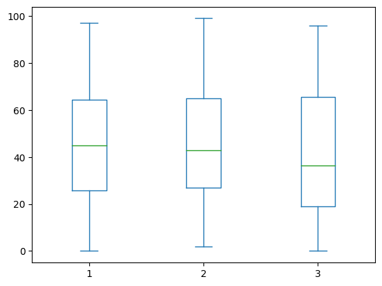

```python
import pandas as pd
import numpy as np
df = pd.DataFrame(np.random.randint(0,100,size=(50,3)), columns=list('123'))
df.head()

for c in  df.sample(int(df.shape[0]*df.shape[1]*0.10)).index:
    df.loc[c,str(np.random.randint(1,4))]=np.nan
print(df)


#part A

print("____________PART A____________")
print(df.isnull().sum().sum())

for col in df.columns:
    print(col,df[col].isnull().sum())
df.dropna(axis = 1,thresh=(df.shape[0]-5)).head()

#part B
print("____________PART B____________")
sum=df.sum(axis=1)
print("SUM IS :\n",sum)
print("\nMAXIMUM SUM IS :",sum.max())
max_sum_row = df.sum(axis=1).idxmax()
print("\nRow index having maximum sum is :" ,max_sum_row)

#part C
print("____________PART C____________")
df = df.drop(max_sum_row ,axis =0)
print("\nDATA Frame AFTER REMOVING THE ROW HAVING MAXIMUM SUM VALUE")
print(df)

#part D
print("____________PART D____________")

sortdf=df.sort_values('1')
sortdf.head()

# PART E
print("____________PART E____________")
df =df.drop_duplicates(subset='1',keep = "first")
print(df)

#part F
print("____________PART F____________")
correlation = df['1'].corr(df['2'])
print("CORRELATION between column 1 and 2 : ", correlation)
covariance = df['2'].cov(df['3'])
print("COVARIANCE between column 2 and 3 :",covariance)

#part G
print("____________PART G____________")
df.plot.box()

#part H
print("____________PART H____________")
df1 =  pd.cut(df['2'],bins=5).head()
print(df1)
```

4. Consider two excel files having attendance of a workshop’s participants for two days. Each file has three fields ‘Name’, ‘Time of joining’, duration (in minutes) where names are unique within a file. Note that duration may take one of three values (30, 40, 50) only. Import the data into two dataframes and do the following: a. Perform merging of the two dataframes to find the names of students who had attended the workshop on both days. b. Find names of all students who have attended workshop on either of the days. c. Merge two data frames row-wise and find the total number of records in the data frame. d. Merge two data frames and use two columns names and duration as multi-row indexes. Generate descriptive statistics for this multi-index.

```python
import numpy as np
import pandas as pd
#taking the data from excel files

dfDay1 = pd.read_excel('Day1.xlsx')
dfDay2 = pd.read_excel('Day2.xlsx')
print(dfDay1.head(),"\n")
print(dfDay2.head())

# Part A
print("___________PART A_____________")
pd.merge(dfDay1,dfDay2,how='inner',on='Name')


#Part B
either_day = pd.merge(dfDay1,dfDay2,how='outer',on='Name')
print(either_day)


#Part C
either_day['Name'].count()

#part D
both_days = pd.merge(dfDay1,dfDay2,how='outer',on=['Name','Duration']).copy()

both_days.fillna(value='-',inplace=True)

both_days.set_index(['Name','Duration'])
```

```
        Name Time of Joining  Duration
0  Abhimanyu        11:00:00        40
1   Abhishek        11:04:00        30
2      Aasif        11:08:00        30
3       Aman        11:01:00        40
4      Anand        11:12:00        50

        Name Time of Joining  Duration
0  Abhimanyu        11:00:00        40
1   Abhishek        11:06:00        30
2  Deepanshu        11:10:00        40
3       Aman        11:09:00        40
4    Anubhav        11:10:00        50
___________PART A_____________
         Name Time of Joining_x  Duration_x Time of Joining_y  Duration_y
```

[output cut: 20 more lines]

| Name | Duration | Time of Joining_x | Time of Joining_y |
| --- | --- | --- | --- |
| Abhimanyu | 40 | 11:00:00 | 11:00:00 |
| Abhishek | 30 | 11:04:00 | 11:06:00 |
| Aasif | 30 | 11:08:00 | - |
| Aman | 40 | 11:01:00 | 11:09:00 |
| Anand | 50 | 11:12:00 | - |
| Anubhav | 30 | 11:10:00 | - |
| Anurag | 30 | 11:11:00 | 11:08:00 |
| Arpit | 40 | 11:07:00 | 11:08:00 |
| Akanksha | 50 | 11:08:00 | - |
| Bhavana | 30 | 11:15:00 | 11:14:00 |
| Deepanshu | 40 | 11:02:00 | 11:10:00 |
| Ishant | 30 | 11:03:00 | 11:00:00 |
| Gourav | 30 | 11:19:00 | - |
| Harshit | 40 | 11:13:00 | 11:09:00 |
| Kartikey | 50 | 11:05:00 | - |
| Anubhav | 50 | - | 11:10:00 |
| Bharat | 30 | - | 11:12:00 |
| Divyanshu | 40 | - | 11:13:00 |
| Deepak | 50 | - | 11:02:00 |
| Jayesh | 30 | - | 11:08:00 |
| Jeeva | 30 | - | 11:06:00 |

5. Taking Iris data, plot the following with proper legend and axis labels: (Download IRIS data from: https://archive.ics.uci.edu/ml/datasets/iris or import it from sklearn.datasets) a. Plot bar chart to show the frequency of each class label in the data. b. Draw a scatter plot for Petal width vs sepal width. c. Plot density distribution for feature petal length. d. Use a pair plot to show pairwise bivariate distribution in the Iris Dataset.

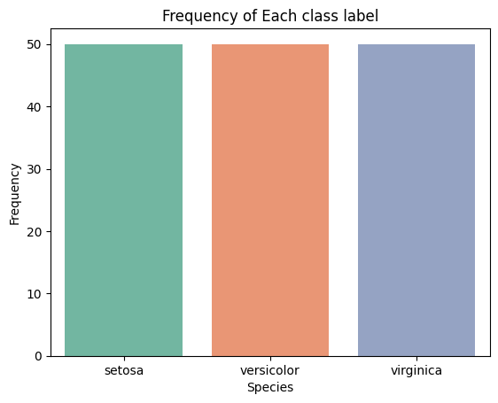

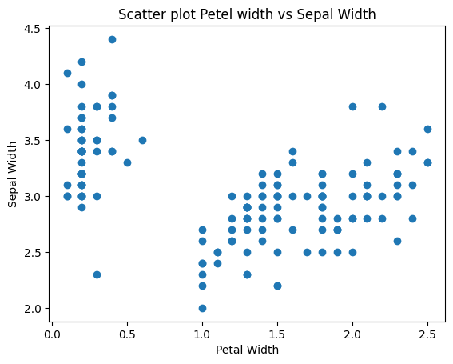

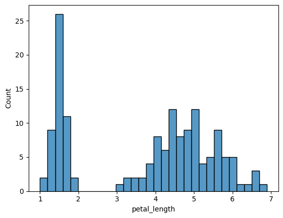

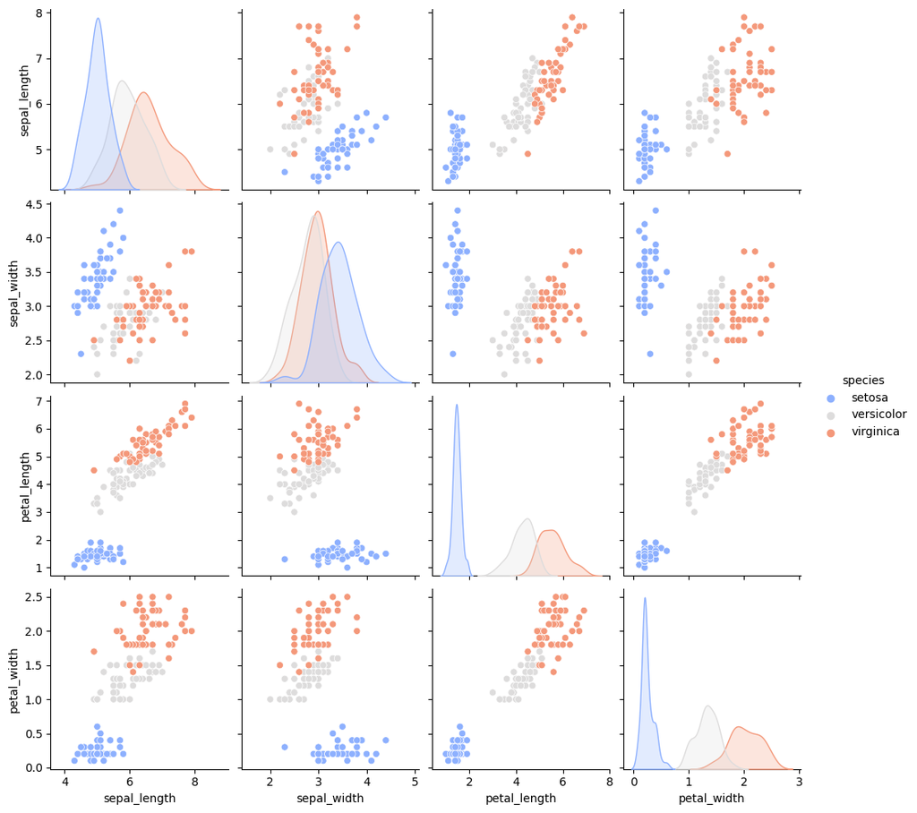

```python
import pandas as pd
import matplotlib.pyplot as plt
import seaborn as sns

iris = sns.load_dataset('iris')
#part A
sns.countplot(x='species',data=iris,palette='Set2')
plt.xlabel('Species')
plt.ylabel('Frequency')
plt.title('Frequency of Each class label')
plt.show()


#part B
plt.scatter(x='petal_width',y='sepal_width',data=iris)
plt.xlabel('Petal Width')
plt.ylabel('Sepal Width')
plt.title("Scatter plot Petel width vs Sepal Width")
plt.show()


#part C
sns.histplot(iris['petal_length'],kde=False,bins=30)
plt.show()

#Part D
sns.pairplot(iris,hue='species',palette='coolwarm')
plt.show()
```

6. Consider any sales training/ weather forecasting dataset a. Compute mean of a series grouped by another series b. Fill an intermittent time series to replace all missing dates with values of previous non-missing date. c. Perform appropriate year-month string to dates conversion. d. Split a dataset to group by two columns and then sort the aggregated results within the groups. e. Split a given dataframe into groups with bin counts.

```python
# Import pandas package
import pandas as pd

# import numpy package
import numpy as np

# Creating a Dataframe
df = pd.read_csv("weather.csv")

# Display the dataframe
print('Created DataFrame:\n',df,"\n")

# PART - A
# Calculating mean on groupby
result = df.groupby('Rainfall')['Sunshine'].mean()
# Display result
print("Result:\n",result)
```

```
Created DataFrame:
      MinTemp  MaxTemp  Rainfall  Evaporation  Sunshine WindGustDir  \
0        8.0     24.3       0.0          3.4       6.3          NW
1       14.0     26.9       3.6          4.4       9.7         ENE
2       13.7     23.4       3.6          5.8       3.3          NW
3       13.3     15.5      39.8          7.2       9.1          NW
4        7.6     16.1       2.8          5.6      10.6         SSE
..       ...      ...       ...          ...       ...         ...
361      9.0     30.7       0.0          7.6      12.1         NNW
362      7.1     28.4       0.0         11.6      12.7           N
363     12.5     19.9       0.0          8.4       5.3         ESE
364     12.5     26.9       0.0          5.0       7.1          NW
365     12.3     30.2       0.0          6.0      12.6          NW

     WindGustSpeed WindDir9am WindDir3pm  WindSpeed9am  ...  Humidity3pm  \
0             30.0         SW         NW           6.0  ...           29
1             39.0          E          W           4.0  ...           36
2             85.0          N        NNE           6.0  ...           69
3             54.0        WNW          W          30.0  ...           56
4             50.0        SSE        ESE          20.0  ...           49
..             ...        ...        ...           ...  ...          ...
361           76.0        SSE         NW           7.0  ...           15
362           48.0        NNW        NNW           2.0  ...           22
363           43.0        ENE        ENE          11.0  ...           47
364           46.0        SSW        WNW           6.0  ...           39
365           78.0         NW        WNW          31.0  ...           13

     Pressure9am  Pressure3pm  Cloud9am  Cloud3pm  Temp9am  Temp3pm  \
0         1019.7       1015.0         7         7     14.4     23.6
1         1012.4       1008.4         5         3     17.5     25.7
2         1009.5       1007.2         8         7     15.4     20.2
3         1005.5       1007.0         2         7     13.5     14.1
4         1018.3       1018.5         7         7     11.1     15.4
..           ...          ...       ...       ...      ...      ...
361       1016.1       1010.8         1         3     20.4     30.0
362       1020.0       1016.9         0         1     17.2     28.2
363       1024.0       1022.8         3         2     14.5     18.3
364       1021.0       1016.2         6         7     15.8     25.9
365       1009.6       1009.2         1         1     23.8     28.6

```

[output cut: 50 more lines]

```
10.4    12.000000
11.0     3.150000
12.2     8.100000
13.2          NaN
14.4    13.200000
16.2     6.650000
16.8     6.500000
17.4     9.050000
18.8     0.000000
19.2     7.500000
19.8     9.100000
22.6     0.200000
25.8     0.600000
39.8     9.100000
Name: Sunshine, dtype: float64
```

7. Consider a data frame containing data about students i.e. name, gender and passing division: a. Perform one hot encoding of the last two columns of categorical data using the get_dummies() function. b. Sort this data frame on the “Birth Month” column (i.e. January to December). Hint: Convert Month to Categorical.

```python
import pandas as pd

df = pd.DataFrame({
    'Name': ['Seema Chopra','Rani Gupta','Aditya Narayan','Sanjeev Sahni',
    'Prakash Kumar','Ritu Agarwal','Akshay Goel','Meeta Kulkarni','Preeti Ahuja','Sunil Das Gupta'
    ,'Sonali Sapre','Rashmi Talwar','Ashish Dubey','Kiran Sharma','Sameer Bansal'],
    'Birth_Month':['January','March','October','February','December','September','August',
    'July','November','April','January','June','May','February','October'],
    'Gender': ['F','F','M','M','M','F','M','F','F','M','F','F','M','F','M'],
    'Pass_Division': [2,1,1,2,3,1,1,2,2,3,1,3,2,2,1]
    })


#PART - A
ohe = pd.get_dummies(data=df, columns=['Gender', 'Pass_Division'])
print(ohe)


#PART - B
month_dict = {'January':1,'February':2,'March':3, 'April':4, 'May':5, 'June':6, 'July':7,
'August':8, 'September':9, 'October':10, 'November':11, 'December':12}
df = df.sort_values('Birth_Month', key = lambda x : x.apply (lambda x : month_dict[x]))
print(df)
```

```
               Name Birth_Month  Gender_F  Gender_M  Pass_Division_1  \
0      Seema Chopra     January         1         0                0
1        Rani Gupta       March         1         0                1
2    Aditya Narayan     October         0         1                1
3     Sanjeev Sahni    February         0         1                0
4     Prakash Kumar    December         0         1                0
5      Ritu Agarwal   September         1         0                1
6       Akshay Goel      August         0         1                1
7    Meeta Kulkarni        July         1         0                0
8      Preeti Ahuja    November         1         0                0
9   Sunil Das Gupta       April         0         1                0
10     Sonali Sapre     January         1         0                1
11    Rashmi Talwar        June         1         0                0
12     Ashish Dubey         May         0         1                0
13     Kiran Sharma    February         1         0                0
```

[output cut: 34 more lines]

8. Consider the following data frame containing a family name, gender of the family member and her/his monthly

income in each record. Write a program in Python using Pandas to perform the following: a. Calculate and display familywise gross monthly income. b. Calculate and display the member with the highest monthly income in a family. c. Calculate and display monthly income of all members with income greater than Rs. 60000.00. d. Calculate and display the average monthly income of the female members in the Shah family.

```python
import pandas as pd

df = pd.DataFrame({
    'Name': ['Shah','Vats','Vats','Kumar','Vats','Kumar','Shah','Shah','Kumar','Vats'],
    'Gender': ['Male','Male','Female','Female','Female','Male','Male','Female','Female','Male'],
    'Monthly_Income': [114000,65000,43150,69500,155000,103000,55000,112400,81030,71900]
    })

#PART - A
df2 = df.groupby('Name').sum()
print(df2)

#PART -C
rslt_df = df[df['Monthly_Income'] > 60000]
print(rslt_df)

#PART -D
df3 = df[df['Name'] == 'Shah' and df['Gender']=='Female']

print(df3)
```

```
       Monthly_Income
Name
Kumar          253530
Shah           281400
Vats           335050
    Name  Gender  Monthly_Income
0   Shah    Male          114000
1   Vats    Male           65000
3  Kumar  Female           69500
4   Vats  Female          155000
5  Kumar    Male          103000
7   Shah  Female          112400
8  Kumar  Female           81030
9   Vats    Male           71900
```

[output not shown]